# Session 4: Homework 2

# 5 Challenge 2: How has the CPI and its components changed over the last few years?

Remember how we used the tidyqant package to download CPI data. In this exercise, I would like you to do the following:

1. You can find [CPI components at FRED](https://fredaccount.stlouisfed.org/public/datalist/843). You should adapt the code from German polls to scrape the FRED website and pull all of the CPI components into a vector. FIY, the list of components is the second table in that webpage.
2. Once you have a vector of components, you can then pass it to `tidyquant::tq_get(get = "economic.data", from = "2000-01-01")` to get all data since January 1, 2000
3. Since the data you download is an index with various starting dates, you need to calculate the yearly, or 12-month change. To do this you need to use the `lag` function, and specifically, `year_change = value/lag(value, 12) - 1`; this means you are comparing the current month’s value with that 12 months ago lag(value, 12).
4. I want you to order components so the higher the yearly change, the earlier does that component appear.
5. You should also make sure that the **All Items** CPI (CPIAUCSL) appears first.
6. Add a `geom_smooth()` for each component to get a sense of the overall trend. 1 You may want to colour the points according to whether yearly change was positive or negative.

Having done this, you should get this graph.

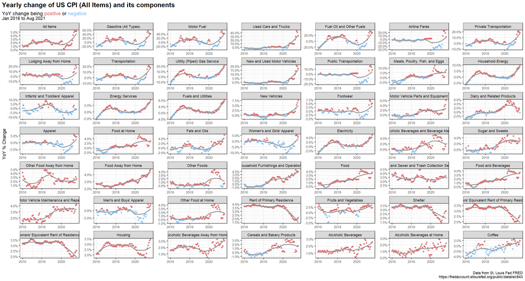

```r
library(rvest)
library(purrr)
url <- "https://fredaccount.stlouisfed.org/public/datalist/843"

# get tables that exist on fredaccount page
tables <- url %>%
  read_html() %>%
  html_nodes(css="table")

# parse HTML tables into a dataframe called cpi
# Use purr::map() to create a list of all tables in URL
cpi <- map(tables, . %>%
             html_table(fill=TRUE)%>%
             clean_names())
# the second table on the page
cpi_table <- cpi[[2]]
cpi_series_id <- cpi_table %>%
  select (series_id) %>%
  pull()
#draw data from tidyquant package
cpi_data <- tidyquant::tq_get(cpi_series_id, get = "economic.data", from =  "2000-01-01")
```

```r
#cut name from title tring
names <- cpi_table %>%
  select(title, series_id) %>%
  mutate(name = str_sub(title,47,-22)) %>%
  rename(symbol = series_id)%>%
  select (-title)
```

```r
#calculate the cpi yoy change
cpi_data_complete<-cpi_data%>%
  mutate(cpi_yoy_change = price/lag(price, 12) - 1)
```

```r
#delate the NA data
cpi_data_complete <- na.omit(cpi_data_complete)
```

```r
#merge two data frames to match name of components with data by symbols
cpi_data_merge <- merge(x=cpi_data_complete, y=names, by= "symbol")
```

```r
#order components so the higher the yearly change, the earlier does that component appear with "all  items" on the top.
cpi_data_arranged <- cpi_data_merge %>%
  group_by(name) %>%
  mutate(mean_cpi_yoy_change = mean(cpi_yoy_change)) %>%
  arrange(desc(mean_cpi_yoy_change))

cpi_data_arranged <- rbind(cpi_data_arranged %>% filter(name=="All Items"),
                           cpi_data_arranged %>% filter(name!="All Items"))


cpi_data_arranged$namef <- factor(cpi_data_arranged$name, levels = unique(cpi_data_arranged$name))
```

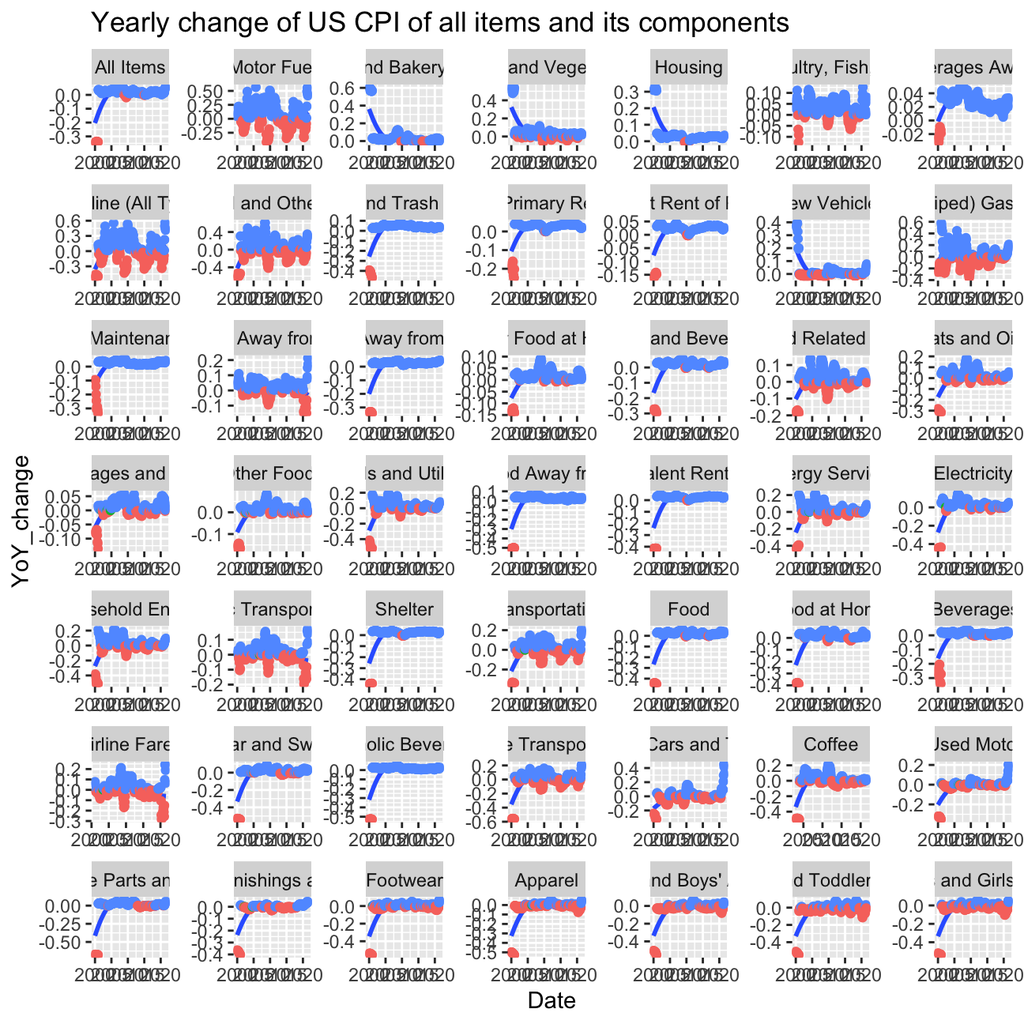

```r
#plot the graph
ggplot(cpi_data_arranged,aes(x=date,y=cpi_yoy_change)) +
  geom_smooth()+
  geom_point(aes(color=factor(sign(cpi_yoy_change))))+
  facet_wrap(~namef,scale="free")+
  labs(x = "Date",
       y = "YoY_change",
       title= "Yearly change of US CPI of all items and its components")+
  theme(legend.position="none") +
  NULL
```

```r
importance_url <- "https://www.bls.gov/cpi/tables/relative-importance/2020.htm"
#get tables that exist on URL
tables_imp <- importance_url %>%
  read_html() %>%
  html_nodes(css="table")
importance <- map(tables_imp, . %>%
               html_table(fill=TRUE)%>%
               clean_names())
```

```r
#get the cpiu of important categories which represent the relative importance
importantnames <- c("Housing","Transportation","Food and beverages", "Medical care", "Education and Communication", "Recreation" , "Apparel")
imp_list <- importance[[1]][-1,] %>%
  mutate(cpiu = as.numeric(u_s_city_average),
         cpiw = as.numeric(u_s_city_average_2)) %>%
  filter(item_and_group %in% importantnames )%>%
  rename(name = item_and_group)
imp_list[1,"name"] <- "Food and Beverages"
```

```r
#arrange the data in the order of cpiu and mutate a factor with relative levels
imp_list_1<- merge(x=imp_list,y=cpi_data_arranged,by="name")%>%
  arrange(desc(cpiu)) %>%
  mutate(impf = factor(name, levels = unique(name)))
```

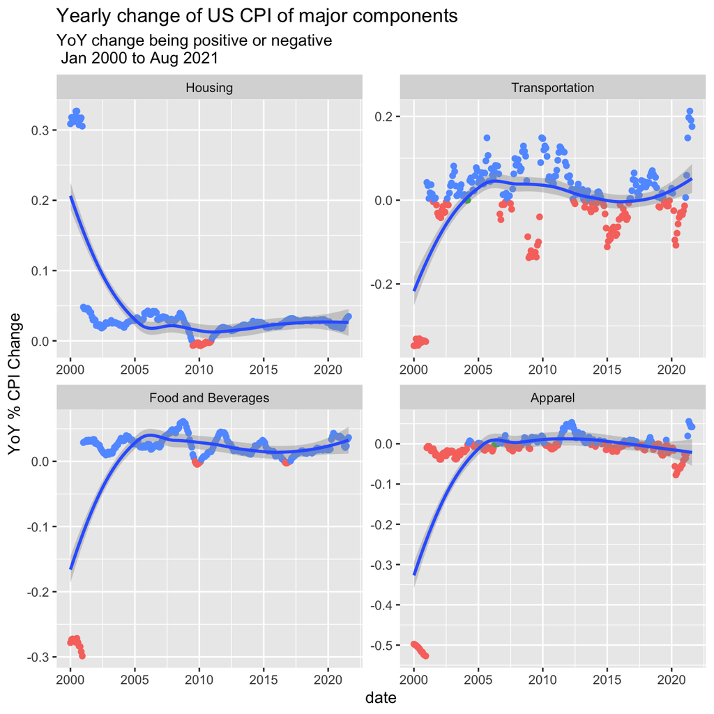

```r
#plot the graph of yoy change of cpi important categories
imp_list_1 %>%
  ggplot(aes(x= date, y= cpi_yoy_change))+
  geom_point(aes(colour = factor(sign(cpi_yoy_change))))+
  geom_smooth()+
  facet_wrap(~impf, scales = "free")+
  labs( y = "YoY % CPI Change", title= "Yearly change of US CPI of major components",subtitle = "YoY change being positive or negative \n Jan 2000 to Aug 2021")+ theme(legend.position="none")
```

[output not shown]